# Actividad 3

## 3.4 Correlaciones Spearman y Heatmap

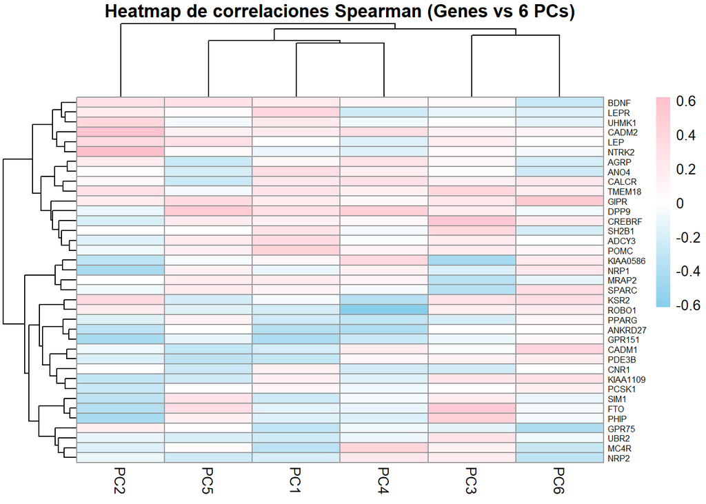

```r
# ------------------------------------------------------------------
# Correlaciones de Spearman: genes vs PCA
# ------------------------------------------------------------------

# Correlaciones Spearman
cor_spearman <- cor(
  genes_pca,
  pca_scores,
  method = "spearman",
  use = "pairwise.complete.obs"
)

# ------------------------------------------------------------------
# Heatmap: genes vs PCA
# ------------------------------------------------------------------

## Heatmap usando pheatmap
pheatmap(
  cor_spearman,
  color = colorRampPalette(c("skyblue", "white", "pink"))(100),
  clustering_distance_rows = "euclidean",
  clustering_distance_cols = "euclidean",
  clustering_method = "ward.D2",
  scale = "none",
  fontsize_row = 6,
  fontsize_col = 10,
  main = "Heatmap de correlaciones Spearman (Genes vs 6 PCs)"
)
```

```r
# Los 5 genes más correlacionados con PC1
pc1_genes <- names(head(sort(abs(cor_spearman[, "PC1"]), decreasing = TRUE), 5))

# Los 5 genes más correlacionados con PC2
pc2_genes <- names(head(sort(abs(cor_spearman[, "PC2"]), decreasing = TRUE), 5))

# Los 5 genes más correlacionados con PC3
pc3_genes <- names(head(sort(abs(cor_spearman[, "PC3"]), decreasing = TRUE), 5))


## No usar, solo referencia
## Heatmap usando datos crudos

#pheatmap(
#  genes_pca_scaled,
#  fontsize_col = 6,
#  color = colorRampPalette(c("green", "white", "orange"))(100),
#  main = "Heatmap de expresión génica (datos escalados)"
#)
# Genes altamanete expresados: PCSK1, SH2B1, LFPR, ADCY3, ANO4, POMC en ciertos pacientes de datos crudos
# Pero la mayoria de genes no tienen un nivel alto de expresion
```

**Interpretación Heatmap**: Análisis de asociación entre expresión génica y patrones del PCA. Los valores representan coeficientes de correlación de Spearman (ρ) que varían de -1 a +1. Correlaciones positivas (rosa) indican que mayores valores del gen se asocian con mayores scores del componente. Correlaciones negativas (azul) indican asociación inversa. El clustering jerárquico agrupa genes con patrones similares.

Los genes mas importantes en las componentes: - **PC1**: GPR151, POMC, LEPR, ANKRD27, ADCY3 - **PC2**: NTRK2, CADM2, PHIP, GPR151, NRP1 - **PC3**: CREBRF, FTO, KIAA0586, PHIP, TMEM18

**Implicaciones** - Los clusters identificados corresponden a **vías metabólicas diferenciadas** capturadas por los componentes principales. - El heatmap confirma que el PCA **capturó estructura biológica significativa** en los datos de expresión génica.

## 3.5 Terciles para PCs

```r
# ------------------------------------------------------------------
# Terciles para PCs
# ------------------------------------------------------------------

# Puntos de corte
corte <- function(x){
  cut(
    x,
    breaks = quantile(x, probs = c(0, 1/3, 2/3, 1), na.rm = TRUE),
    include.lowest = TRUE,
    labels = c("T1", "T2", "T3")
  )
}

# Asignar los cortes a columnas de PCs en df
df$PC1_t <- corte(df$PC1)
df$PC2_t <- corte(df$PC2)
df$PC3_t <- corte(df$PC3)

# ------------------------------------------------------------------
# Tabla descriptiva
# ------------------------------------------------------------------

# PC1

tabla_PC1 <- df %>%
  select(PC1_t, all_of(genes_interes)) %>%
  tbl_summary(
    by = PC1_t,
    type = list(
      all_of(genes_interes) ~ "continuous"
    ),
    statistic = all_continuous() ~ "{median} ({p25}–{p75})",
    digits = all_continuous() ~ 1,
  ) %>%
  add_p(
    test = list(all_of(genes_interes) ~ "kruskal.test"),
    pvalue_fun = ~ style_pvalue(.x, digits = 3)
  ) %>%
  # Mejorar formato
  modify_header(
    label = "**Gen**"
  )

# PC2

tabla_PC2 <- df %>%
  select(PC2_t, all_of(genes_interes)) %>%
  tbl_summary(
    by = PC2_t,
    type = list(
      all_of(genes_interes) ~ "continuous"
    ),
    statistic = all_continuous() ~ "{median} ({p25}–{p75})",
    digits = all_continuous() ~ 1,
  ) %>%
  add_p(
    test = list(all_of(genes_interes) ~ "kruskal.test"),
    pvalue_fun = ~ style_pvalue(.x, digits = 3)
  ) %>%
  # Mejorar formato
  modify_header(
    label = "**Gen**"
  )

# PC3

tabla_PC3 <- df %>%
  select(PC3_t, all_of(genes_interes)) %>%
  tbl_summary(
    by = PC3_t,
    type = list(
      all_of(genes_interes) ~ "continuous"
    ),
    statistic = all_continuous() ~ "{median} ({p25}–{p75})",
    digits = all_continuous() ~ 1,
  ) %>%
  add_p(
    test = list(all_of(genes_interes) ~ "kruskal.test"),
    pvalue_fun = ~ style_pvalue(.x, digits = 3)
  ) %>%
  # Mejorar formato
  modify_header(
    label = "**Gen**"
  )

# Unir todas las tablas

# Unir las tablas
tabla_combinada <- tbl_merge(
  tbls = list(tabla_PC1, tabla_PC2, tabla_PC3),
  tab_spanner = c("**Componente 1**", "**Componente 2**", "**Componente 3**")
) %>%
  modify_caption(
    "**Tabla 3.** Expresión génica dividida por terciles de los tres componentes principales del PCA. Los genes se presentan con la mediana debido a distribución no normal. Los componentes principales representan patrones combinados de expresión génica que explican la máxima varianza en los datos."
  )


# Mostrar tabla combinada
tabla_combinada
```

**Tabla 3.** Expresión génica dividida por terciles de los tres componentes principales del PCA. Los genes se presentan con la mediana debido a distribución no normal. Los componentes principales representan patrones combinados de expresión génica que explican la máxima varianza en los datos.

| **Gen** | **Componente 1** **T1** N = 20<sup>1</sup> | **Componente 1** **T2** N = 19<sup>1</sup> | **Componente 1** **T3** N = 20<sup>1</sup> | **Componente 1** **p-value**<sup>2</sup> | **Componente 2** **T1** N = 20<sup>1</sup> | **Componente 2** **T2** N = 19<sup>1</sup> | **Componente 2** **T3** N = 20<sup>1</sup> | **Componente 2** **p-value**<sup>2</sup> | **Componente 3** **T1** N = 20<sup>1</sup> | **Componente 3** **T2** N = 19<sup>1</sup> | **Componente 3** **T3** N = 20<sup>1</sup> | **Componente 3** **p-value**<sup>2</sup> |
| --- | --- | --- | --- | --- | --- | --- | --- | --- | --- | --- | --- | --- |
| ADCY3 | -0.8 (-0.9–-0.5) | -0.5 (-0.8–-0.2) | -0.2 (-0.8–-0.2) | 0.016 | -0.2 (-0.8–-0.2) | -0.5 (-0.8–-0.2) | -0.5 (-0.8–-0.2) | 0.490 | -0.5 (-0.9–-0.4) | -0.5 (-0.8–-0.2) | -0.4 (-0.8–-0.2) | 0.351 |
| AGRP | 0.2 (-0.2–0.5) | 0.2 (-0.2–0.3) | 0.2 (-0.2–0.7) | 0.707 | 0.2 (-0.2–0.3) | 0.2 (0.2–0.3) | 0.2 (0.0–0.7) | 0.550 | 0.2 (-0.2–0.6) | 0.3 (0.2–0.7) | 0.2 (-0.2–0.5) | 0.657 |
| ANKRD27 | 0.8 (-0.2–0.8) | -0.2 (-0.4–2.1) | -0.4 (-0.4–-0.2) | 0.046 | 0.3 (-0.2–2.1) | 0.8 (-0.4–0.8) | -0.4 (-0.4–-0.2) | 0.040 | -0.2 (-0.4–1.5) | -0.2 (-0.4–0.8) | -0.2 (-0.4–2.1) | 0.719 |
| ANO4 | -0.5 (-0.8–-0.3) | -0.5 (-0.5–-0.3) | -0.3 (-0.5–-0.2) | 0.208 | -0.5 (-0.5–-0.3) | -0.3 (-0.5–-0.1) | -0.5 (-0.5–-0.3) | 0.117 | -0.5 (-0.5–-0.3) | -0.3 (-0.5–-0.2) | -0.5 (-0.5–-0.2) | 0.861 |
| BDNF | -0.8 (-0.9–-0.7) | -0.8 (-0.9–-0.7) | -0.7 (-0.8–1.2) | 0.208 | -0.8 (-0.9–-0.7) | -0.7 (-0.9–-0.7) | -0.7 (-0.8–1.2) | 0.154 | -0.8 (-0.9–0.3) | -0.7 (-0.8–1.2) | -0.8 (-0.9–-0.7) | 0.587 |
| CADM1 | -0.4 (-0.6–1.0) | -0.1 (-0.6–1.0) | -0.6 (-0.9–-0.4) | 0.029 | -0.2 (-0.6–1.0) | -0.4 (-0.6–1.0) | -0.4 (-0.6–-0.3) | 0.512 | -0.5 (-0.9–1.0) | -0.4 (-0.6–1.0) | -0.4 (-0.6–-0.1) | 0.507 |
| CADM2 | -0.7 (-0.7–-0.6) | -0.7 (-0.7–1.2) | -0.6 (-0.7–1.2) | 0.367 | -0.7 (-0.8–-0.7) | -0.7 (-0.7–1.2) | 1.2 (-0.6–1.2) | <0.001 | -0.6 (-0.7–-0.6) | -0.7 (-0.7–1.2) | -0.6 (-0.7–1.2) | 0.399 |
| CALCR | -0.3 (-1.0–1.0) | -0.3 (-0.7–1.0) | -0.2 (-0.3–1.5) | 0.308 | -0.3 (-0.8–1.5) | -0.3 (-0.7–1.0) | 0.4 (-0.6–1.5) | 0.337 | -0.3 (-0.8–1.0) | -0.3 (-0.6–2.0) | -0.3 (-0.7–1.0) | 0.441 |
| CNR1 | -0.2 (-0.3–0.7) | -0.2 (-1.9–0.7) | -0.2 (-0.3–0.7) | 0.667 | -0.2 (-0.3–0.7) | -0.2 (-0.3–0.7) | -0.2 (-1.1–0.7) | 0.996 | 0.7 (-0.3–0.7) | -0.2 (-0.3–0.7) | -0.3 (-1.9–0.7) | 0.151 |
| CREBRF | 0.4 (-1.4–0.7) | 0.6 (-1.4–0.7) | 0.7 (-1.4–0.8) | 0.322 | 0.7 (0.4–0.8) | 0.6 (-1.4–0.7) | 0.1 (-1.4–0.8) | 0.316 | -1.4 (-1.4–0.7) | 0.6 (-1.4–0.7) | 0.7 (0.6–0.8) | 0.001 |
| DPP9 | -1.2 (-1.5–-0.2) | 0.7 (-0.3–0.8) | -0.1 (-0.7–0.8) | 0.025 | 0.3 (-0.7–0.8) | -0.3 (-1.2–0.7) | -0.3 (-1.2–0.8) | 0.302 | -0.3 (-1.5–0.8) | -0.3 (-1.2–0.7) | 0.7 (-0.7–0.8) | 0.369 |
| FTO | 0.6 (0.2–0.9) | 0.6 (-0.3–0.9) | 0.6 (-0.4–0.9) | 0.756 | 0.9 (0.6–1.7) | 0.6 (-0.3–0.9) | -0.3 (-1.4–0.9) | 0.025 | 0.6 (-0.3–0.6) | 0.6 (-1.4–0.9) | 0.9 (0.8–1.7) | <0.001 |
| GIPR | -0.4 (-0.8–0.0) | 0.0 (-0.2–1.6) | -0.2 (-0.6–0.7) | 0.042 | -0.2 (-0.6–1.5) | -0.2 (-1.0–0.0) | -0.2 (-0.2–0.0) | 0.402 | -0.2 (-0.6–0.0) | -0.2 (-0.6–0.0) | 0.0 (-0.4–1.6) | 0.128 |
| GPR151 | 0.4 (0.0–0.7) | 0.5 (-0.2–0.7) | -0.2 (-1.2–0.2) | 0.008 | 0.6 (0.3–1.0) | -0.2 (-1.2–0.5) | -0.2 (-0.7–0.4) | 0.002 | 0.3 (-0.2–0.7) | 0.1 (-1.2–0.5) | 0.2 (-0.2–0.6) | 0.481 |
| GPR75 | 0.6 (0.3–0.7) | 0.3 (-1.1–0.7) | 0.1 (-1.5–0.5) | 0.090 | 0.3 (-1.5–0.6) | 0.4 (-1.1–0.7) | 0.4 (-0.5–0.7) | 0.513 | 0.5 (-0.5–0.6) | 0.4 (-1.1–0.7) | 0.2 (-1.1–0.6) | 0.498 |
| KIAA0586 | 0.5 (-0.5–0.8) | 0.7 (-0.5–0.9) | 0.7 (-0.5–0.9) | 0.822 | 0.8 (0.5–0.9) | 0.7 (0.5–0.9) | -0.5 (-1.4–0.8) | 0.053 | 0.9 (0.6–0.9) | 0.5 (-0.5–0.9) | 0.3 (-0.5–0.7) | 0.019 |
| KIAA1109 | -0.5 (-0.7–0.4) | -0.5 (-0.7–0.3) | -0.5 (-0.7–0.4) | 0.830 | -0.1 (-0.5–0.4) | -0.5 (-0.7–0.3) | -0.6 (-1.6–-0.1) | 0.028 | -0.5 (-1.1–-0.5) | -0.5 (-0.7–0.4) | -0.1 (-0.7–0.4) | 0.250 |
| KSR2 | -0.2 (-0.6–0.2) | 0.0 (-0.4–0.6) | -0.2 (-0.8–0.2) | 0.570 | -0.4 (-0.8–0.1) | -0.2 (-0.4–0.0) | 0.2 (-0.4–2.0) | 0.041 | -0.3 (-0.8–-0.2) | 0.0 (-0.2–0.6) | 0.0 (-0.4–0.6) | 0.027 |
| LEP | 1.0 (-0.5–1.1) | 1.0 (-0.7–1.1) | 1.0 (0.4–1.1) | 0.393 | -0.3 (-0.7–1.1) | 1.0 (-0.7–1.1) | 1.0 (1.0–1.1) | 0.022 | 1.0 (-0.7–1.1) | 1.0 (-0.3–1.1) | 1.0 (-0.5–1.1) | 0.525 |
| LEPR | -0.9 (-0.9–-0.2) | -0.2 (-0.9–0.0) | -0.2 (-0.7–0.0) | 0.057 | -0.8 (-0.9–-0.2) | -0.2 (-0.9–0.0) | -0.2 (-0.9–0.0) | 0.399 | -0.2 (-0.9–0.0) | -0.7 (-0.9–0.0) | -0.4 (-0.9–-0.2) | 0.778 |
| MC4R | 0.5 (0.0–1.2) | 0.1 (0.0–0.9) | -0.5 (-0.5–0.5) | 0.039 | 0.9 (-0.2–1.1) | 0.1 (0.0–1.2) | 0.1 (-0.2–0.9) | 0.771 | 0.0 (-0.5–0.9) | 0.1 (0.0–1.2) | 0.5 (0.0–1.1) | 0.443 |
| MRAP2 | -0.2 (-0.5–-0.2) | -0.2 (-0.5–-0.2) | -0.2 (-0.3–-0.1) | 0.246 | -0.2 (-0.5–-0.2) | -0.2 (-0.5–-0.2) | -0.3 (-0.5–-0.2) | 0.884 | -0.2 (-0.4–2.4) | -0.2 (-0.5–-0.2) | -0.3 (-0.5–-0.2) | 0.070 |
| NRP1 | 0.7 (0.0–0.8) | 0.0 (0.0–0.7) | 0.0 (-1.6–1.0) | 0.674 | 0.7 (0.0–1.3) | 0.7 (0.0–0.8) | -1.2 (-1.6–0.4) | 0.009 | 0.3 (0.0–0.8) | 0.2 (-1.6–1.3) | 0.0 (-1.4–0.7) | 0.454 |
| NRP2 | 0.9 (-1.2–0.9) | -0.6 (-1.7–0.9) | -0.9 (-1.2–0.5) | 0.326 | -0.6 (-1.4–0.9) | -0.6 (-1.2–0.9) | -0.1 (-1.4–0.9) | 0.914 | -0.9 (-1.4–0.9) | -0.6 (-1.2–0.9) | 0.8 (-1.2–0.9) | 0.399 |
| NTRK2 | 1.1 (-0.4–1.1) | -0.4 (-0.6–1.3) | 1.1 (-0.6–1.1) | 0.943 | -0.4 (-0.6–-0.4) | 1.1 (-0.6–1.1) | 1.1 (1.1–1.3) | <0.001 | 1.1 (-0.5–1.1) | 1.1 (-0.4–1.1) | -0.4 (-0.6–1.3) | 0.907 |
| PCSK1 | -0.5 (-1.2–-0.1) | -0.5 (-1.2–0.0) | -0.5 (-0.7–-0.3) | 0.871 | -0.3 (-0.6–0.0) | -0.5 (-1.2–-0.3) | -0.6 (-1.2–-0.5) | 0.050 | -0.5 (-1.0–-0.3) | -0.5 (-0.7–-0.2) | -0.5 (-1.2–0.0) | 0.956 |
| PDE3B | 0.9 (0.3–0.9) | 0.3 (0.2–0.9) | 0.2 (-0.6–0.9) | 0.089 | 0.9 (0.2–0.9) | 0.9 (0.2–0.9) | 0.3 (0.2–0.9) | 0.448 | 0.6 (-0.5–0.9) | 0.9 (0.2–0.9) | 0.3 (0.2–0.9) | 0.900 |
| PHIP | 0.1 (-0.9–1.1) | 0.1 (-0.9–0.1) | 0.1 (-0.2–0.1) | 0.518 | 0.1 (0.1–1.1) | 0.1 (-0.9–0.1) | -0.2 (-0.9–0.1) | 0.019 | 0.1 (-0.9–0.1) | 0.1 (-0.9–0.1) | 0.1 (0.1–2.0) | 0.002 |
| POMC | -0.6 (-0.7–-0.3) | -0.3 (-0.6–-0.2) | -0.2 (-0.6–0.1) | 0.010 | -0.3 (-0.6–-0.2) | -0.3 (-0.7–0.1) | -0.3 (-0.6–-0.2) | 0.864 | -0.6 (-0.7–-0.2) | -0.3 (-0.7–0.1) | -0.3 (-0.6–-0.1) | 0.283 |
| PPARG | -0.4 (-0.8–1.2) | -0.4 (-1.0–0.1) | -1.0 (-1.1–-0.4) | 0.064 | -0.4 (-1.0–0.3) | -0.4 (-1.0–0.1) | -0.7 (-1.1–-0.2) | 0.258 | -0.4 (-1.0–0.4) | -0.4 (-1.0–0.1) | -0.4 (-1.0–-0.2) | 0.510 |
| ROBO1 | 0.6 (-0.5–0.7) | 0.6 (0.2–0.8) | 0.2 (-1.3–0.6) | 0.158 | 0.4 (-1.3–0.7) | -0.5 (-2.2–0.8) | 0.6 (0.2–0.6) | 0.401 | 0.4 (-1.3–0.8) | 0.2 (-0.5–0.6) | 0.6 (0.2–0.8) | 0.527 |
| SH2B1 | -0.3 (-1.1–-0.1) | -0.2 (-0.9–-0.1) | -0.2 (-0.9–0.0) | 0.317 | -0.2 (-0.9–-0.1) | -0.2 (-0.9–-0.1) | -0.2 (-0.9–0.0) | 0.917 | -1.1 (-1.3–-0.2) | -0.1 (-0.2–0.1) | -0.2 (-0.9–-0.1) | <0.001 |
| SIM1 | 1.2 (0.4–1.2) | 1.0 (-0.2–1.2) | 0.4 (-0.6–1.2) | 0.144 | 1.2 (0.4–1.2) | 1.0 (-0.2–1.2) | 0.4 (-0.7–1.2) | 0.155 | -0.2 (-0.2–1.2) | 1.0 (-0.9–1.2) | 1.2 (1.0–1.2) | 0.310 |
| SPARC | -0.1 (-0.3–0.0) | 0.0 (-1.2–1.1) | 0.0 (-0.7–0.9) | 0.687 | 0.0 (-0.3–1.1) | 0.0 (-0.2–0.8) | -0.3 (-1.2–0.8) | 0.195 | 0.0 (-0.1–0.9) | 0.0 (-0.2–0.8) | -0.3 (-1.2–0.4) | 0.050 |
| TMEM18 | -0.3 (-1.3–0.2) | 0.7 (-0.3–1.0) | 0.6 (-0.4–0.8) | 0.030 | -0.3 (-0.7–0.9) | -0.2 (-0.7–0.8) | 0.7 (-0.3–0.8) | 0.179 | -0.7 (-0.7–0.7) | 0.6 (-0.7–0.7) | 0.8 (-0.3–1.0) | 0.014 |
| UBR2 | 0.7 (-0.7–1.3) | 0.7 (-0.7–1.5) | -0.7 (-0.7–0.7) | 0.116 | 0.7 (-0.7–1.3) | 0.7 (-0.7–1.3) | -0.7 (-0.7–1.3) | 0.664 | -0.7 (-0.7–0.7) | 0.7 (-0.7–1.3) | 0.7 (-0.7–1.5) | 0.190 |
| UHMK1 | -0.6 (-0.7–0.7) | -0.7 (-2.0–-0.6) | 0.7 (-0.6–0.7) | 0.022 | -0.7 (-2.0–0.0) | -0.6 (-0.7–0.7) | 0.7 (-0.6–0.7) | 0.032 | -0.6 (-1.4–0.7) | 0.7 (-0.7–0.7) | -0.7 (-1.4–0.7) | 0.309 |

<sup>1</sup> Median (Q1–Q3)  
<sup>2</sup> Kruskal-Wallis rank sum test

**Interpretación de la expresión génica dividida por terciles de los tres componentes principales del PCA**: La tabla muestra diferencias significativas en la expresión de varios genes entre pacientes con distintos perfiles metabólicos (representados por los componentes del PCA). Los genes más relevantes son aquellos con valores p < 0.05, que indican asociación estadísticamente significativa con los PCs.

En el PC1, los genes significativos (p < 0.05) son: *ANKRD27, DPP9, GIPR, **GPR151**, MC4R, **POMC**, TMEM18, ADCY3, CADM1, UHMK1*. Estos genes estan asociados a la obesidad, metabolismo energético y regulación del apetito.

En el PC2, los genes significativos (p < 0.05) son: *ANKRD27, **CADM2**, FTO, **GPR151**, KIAA1109, KSR2, LEP, **NRP1**, **NTRK2**, PHIP, UHMK1*. Estos genes estan asociados a patrones inflamatorios.

En el PC3, los genes significativos (p < 0.05) son: **CREBRF**, **FTO**, KIAA0586, KSR2, **PHIP**, **SH2B1**, TMEM18. Estos genes estan asociados a la regulación central del apetito y gasto energético y al desarrollo del tejido adiposo.